# Protocol for Implementing Distributed Cox Regression on CCASAnet

for Chile (lead site)

Author

Kaixing Liu

Published

August 8, 2025

Modified

August 13, 2025

## 1 Preparation

### 1.1 Action 1

1. **Create/Choose a directory in your local machine** at your discretion.
   - For example, I created a local directory with absolute path, `"/Users/lkx220/Desktop/chile"`.
2. **Download from the cloud** (e.g., OneDrive) the following items,
   - **R scripts**, `distributed-analysis-ccasanet.R` and `authentic-distributed-analysis.R`, to the local directory specified in **1.**, say `"/Users/lkx220/Desktop/chile"`;
   - **site-specific individual-level data**: Chile shall download `chile_all_trt.rds` and `chile_all_vl.rds` to the same local directory;
   - **global set-up file**: `setup.rds` to the same local directory;
   - **site-specific instruction**: Chile should download `protocol-CCASAnet-Chile.html` to anywhere in your local machine (this file is meant to guide you the procedures of implementation of this distributed analysis);

#### 1.1.1 Check

**Make sure** that R scripts, set-up file, and the data are in the same local directory, shown below.

**This local directory** (chosen at your discretion) would be the **working directory in R later**.

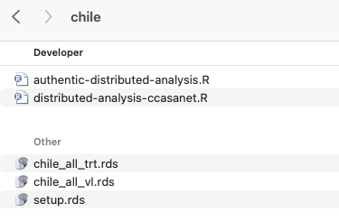

### 1.2 Action 2

1. Open RStudio or R and set working directory as the local directory you chosen in **Preparation**.

   You may as well run the command below in your R console.

   ```r
   # setwd("your-working-directory")
   setwd("/Users/lkx220/Desktop/chile") # my example
   ```

2. Source the code and import data and set-up file.

   Please execute code below in console.

   ```r
   source("distributed-analysis-ccasanet.R")
   source("authentic-distributed-analysis.R")
   chile.vl = readRDS("chile_all_vl.rds")
   chile.trt = readRDS("chile_all_trt.rds")
   setup = readRDS("setup.rds")
   # prepare data for different scenarios
   # for Chile
   ## you can just ignore warning messages
   chile.vl.cc = chile.vl %>% subset(!is.na(sex_mode) & !is.na(cd4_v_initial_sqrt) & !is.na(rna_v_initial_log))
   chile.vl.mi = mice.local.merge(mice(chile.vl %>% select(all_of(setup[["vl.imp.var"]])), m=setup[["no.of.imputation"]], method = "pmm",
                                    seed = setup[["seed"]], printFlag = FALSE), m=setup[["no.of.imputation"]])
   chile.trt.cc = chile.trt %>% subset(!is.na(sex_mode) & !is.na(cd4_v_initial_sqrt) & !is.na(rna_v_initial_log))
   chile.trt.mi = mice.local.merge(mice(chile.trt %>% select(all_of(setup[["trt.imp.var"]])), m=setup[["no.of.imputation"]], method = "pmm",
                                    seed = setup[["seed"]], printFlag = FALSE), m=setup[["no.of.imputation"]])
   ```

## 2 Implementation

### 2.1 Virologic Failure, Complete-Case Analysis

**Initialization**

1. Chile runs the command below.

   After running this, there will be a `control.json` file in the newly generated directory, `"vl/complete-case"` in the chosen local directory.

   ```r
   control <- list(project_name = 'virologic_failure_distributed_survival_analysis_ccasanet',
               step = 'initialize',
               sites = c("chile", "brazil", "mexico"),
               heterogeneity = TRUE,
               model = 'ODAC',
               family = 'cox',
               outcome = "Surv(vlfailure_status.years, vlfailure_status==\"virologic failure\")",
               variables = c('sex_mode', 'age', 'clinicalAIDS', 'cd4_v_initial_sqrt', 'rna_v_initial_log', 'calendaryear', 'initialARTtype'),
               xlev = list(sex_mode=c('Female','Male-MSM', "Male-Other"), clinicalAIDS=c('Not clinical AIDS','Clinical AIDS'), initialARTtype=c('NNRTI','PI','INSTI')),
               optim_maxit = 10000,
               init_method = "meta",
               optim_method = "Nelder-Mead",
               lead_site = "chile",
               upload_date = as.character(Sys.time()))
   set.seed(setup[["seed"]])
   pda.setup(leadsite = "chile", control, dir = getwd(), m = 1, complete = TRUE, outcome = "vl")
   ```

   **CHECK**

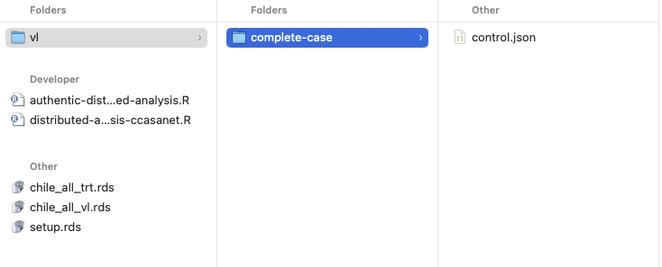

   and

   the “step” in `control.json` file in `"./vl/complete-case"` should be “initialize” (you can just open the `control.json` file or preview it if possible).
2. Chile shall upload the `control.json` file in `"./vl/complete-case"` to the `"./vl/complete-case"` directory in the cloud.

   **—Wait for Brazil and Mexico to upload their `_initialize.json` file to the cloud.—**
3. After downloading `brazil_initialize.json` and `mexico_initialize.json` in the `"./vl/complete-case"` directory in OneDrive to local `"./vl/complete-case"` directory,

   **CHECK**

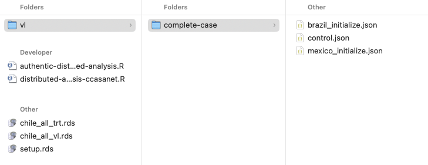

   Then run the command below. The same `control.json` file will be updated automatically.

   ```r
   set.seed(setup[["seed"]])
   pda.local(chile.vl.cc, "chile", getwd(), m = 1, complete = TRUE, outcome = "vl")
   ```

   **CHECK**

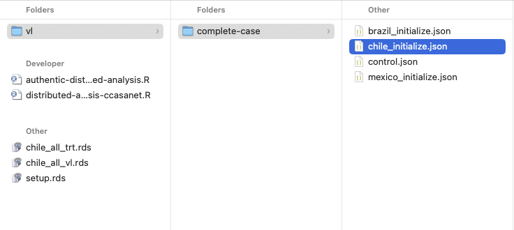

   and

   The “step” in `control.json` file in `"./vl/complete-case"` should be “derive” now (you can just open the `control.json` file or preview it if possible).
4. Chile uploads the updated `control.json` file in `"./vl/complete-case"` in local machine to `"./vl/complete-case"` in OneDrive.

**Derivation**

**—Wait for Brazil and Mexico to upload their `_derive.json` file.—**

1. After downloading `brazil_derive.json` and `mexico_derive.json` from `"./vl/complete-case"` in the cloud to local `"./vl/complete-case"`,

   **CHECK**

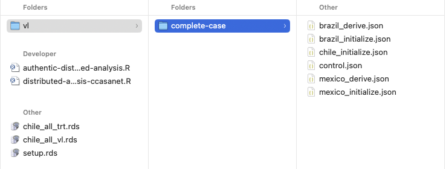

   Then run the command below.

   ```r
   set.seed(setup[["seed"]])
   pda.derive(chile.vl.cc, "chile", getwd(), m = 1, complete = TRUE, outcome = "vl")
   ```

   **CHECK (`chile_derive.json`)**

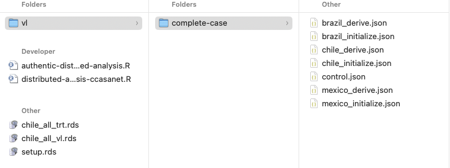

   and

   the “step” in `control.json` file in `"./vl/complete-case"` should be “estimate” now (you can just open the `control.json` file or preview it if possible).

**Estimation**

1. Chile runs this.

   ```r
   set.seed(setup[["seed"]])
   pda.estimate(chile.vl.cc, "chile", getwd(), m = 1, complete = TRUE, outcome = "vl")
   ```

   **CHECK (`chile_estimate.json`)**

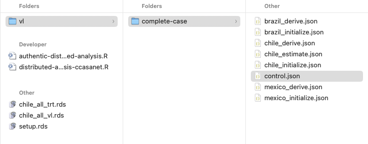

**Results**

1. Chile runs this.

```r
vl.dist.cc = pda.summary("chile", c("brazil", "mexico"), getwd(), 1, complete = TRUE, outcome="vl")
saveRDS(vl.dist.cc, file = "vl_dist_cc.rds")

vl.meta.cc = meta.mi(dist.meta(c("chile", "brazil", "mexico"), getwd(), 1, complete = TRUE, outcome="vl"))
saveRDS(vl.meta.cc, file = "vl_meta_cc.rds")
```

2. **CHECK** and upload `vl_dist_cc.rds` and `vl_meta_cc.rds` in the local directory to parental OneDrive folder.

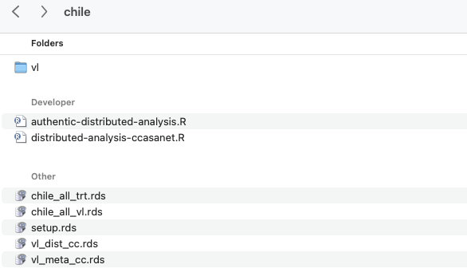

**—You are Done for federated analysis in this scenario.—**

Now you probably get familiar with the procedure.

For virologic failure with multiple imputation later, the procedures are the same overall except that we will do this per imputed data set.

No worries. The command given below realize this in parallel and this means you still just need run it once.

But you need do more when downloading and uploading files since we have multiple imputed data sets.

### 2.2 Virologic Failure, with Multiple Imputation

**Initialization**

1. Chile runs the command below.

   ```r
   control <- list(project_name = 'virologic_failure_distributed_survival_analysis_ccasanet',
               step = 'initialize',
               sites = c("chile", "brazil", "mexico"),
               heterogeneity = TRUE,
               model = 'ODAC',
               family = 'cox',
               outcome = "Surv(vlfailure_status.years, vlfailure_status==\"virologic failure\")",
               variables = c('sex_mode', 'age', 'clinicalAIDS', 'cd4_v_initial_sqrt', 'rna_v_initial_log', 'calendaryear', 'initialARTtype'),
               xlev = list(sex_mode=c('Female','Male-MSM', "Male-Other"), clinicalAIDS=c('Not clinical AIDS','Clinical AIDS'), initialARTtype=c('NNRTI','PI','INSTI')),
               optim_maxit = 10000,
               init_method = "meta",
               optim_method = "Nelder-Mead",
               lead_site = "chile",
               upload_date = as.character(Sys.time()))
   set.seed(setup[["seed"]])
   pda.setup(leadsite = "chile", control, dir = getwd(), m = setup[["no.of.imputation"]], outcome = "vl")
   ```

   **CHECK (newly generated directories indexed by number 1-10 in `./vl` and `control.json` file within each number-indexed directory)**

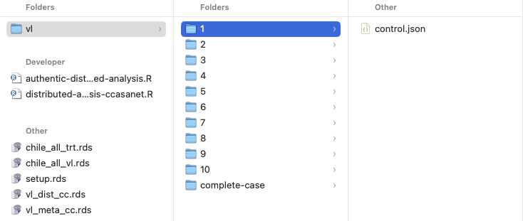

   and

   the “step” in `control.json` file in `"./vl/1"` should be “initialize” (you can just open the `control.json` file or preview it if possible).
2. Chile uploads each `control.json` file in the number-indexed directory to corresponding number-indexed directory in OneDrive.

   **—Wait for Brazil and Mexico to obtain and upload their `_initialize.json` file.—**
3. After downloading each pair of `brazil_initialize.json` and `mexico_initialize.json` in the number-indexed directory in OneDrive to corresponding local number-indexed directory,

   **CHECK**

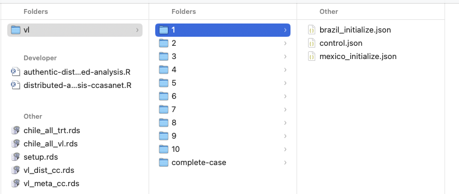

   Run the command below. The same `control.json` file will be updated automatically.

   ```r
   set.seed(setup[["seed"]])
   pda.local(chile.vl.mi, "chile", getwd(), m = setup[["no.of.imputation"]], outcome = "vl")
   ```

   **CHECK (`chile_initialize.json`)**

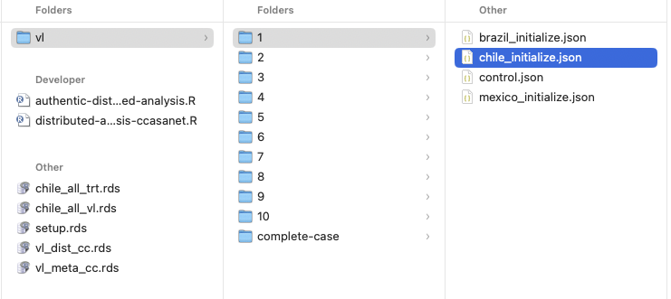

   and

   the “step” in `control.json` file in `"./vl/1"` should be “derive” (you can just open the `control.json` file or preview it if possible).
4. Chile updates each `control.json` file in the number-indexed directory to corresponding number-indexed directory in OneDrive.

**Derivation**

**—Wait for Brazil and Mexico to upload their `_derive.json` file.—**

1. After downloading each pair of `brazil_derive.json` and `mexico_derive.json` in number-indexed directories in OneDrive to corresponding local number-indexed directories,

   **CHECK**

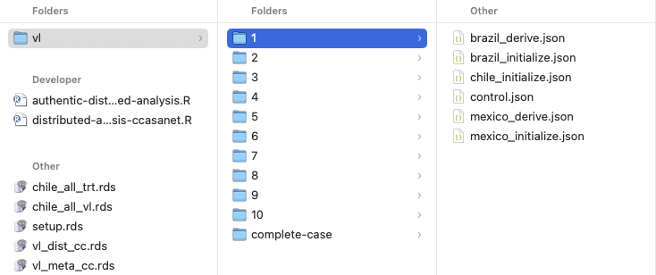

   Then run the command below.

   ```r
   set.seed(setup[["seed"]])
   pda.derive(chile.vl.mi, "chile", getwd(), m = setup[["no.of.imputation"]], outcome="vl")
   ```

   **CHECK**

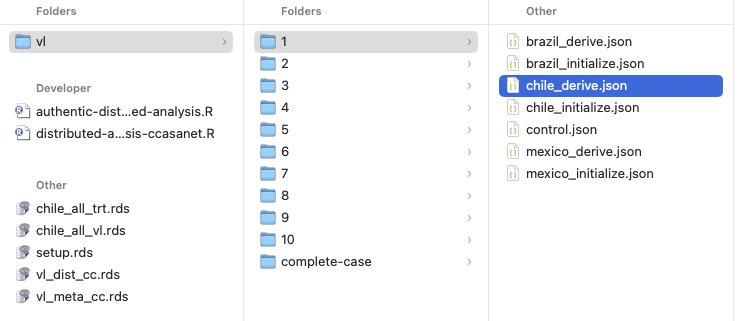

   and

   the “step” in `control.json` file in `"./vl/1"` should be “estimate” (you can just open the `control.json` file or preview it if possible).

**Estimation**

1. Chile runs this.

   ```r
   set.seed(setup[["seed"]])
   pda.estimate(chile.vl.mi, "chile", getwd(), m = setup[["no.of.imputation"]], outcome="vl")
   ```

**Results**

1. Chile runs this.

```r
vl.dist.mi = pda.summary("chile", c("brazil", "mexico"), getwd(), m = setup[["no.of.imputation"]], outcome="vl")
saveRDS(vl.dist.mi, file = "vl_dist_mi.rds")

vl.meta.mi = meta.mi(dist.meta(c("chile", "brazil", "mexico"), getwd(), m = setup[["no.of.imputation"]], outcome="vl"))
saveRDS(vl.meta.mi, file = "vl_meta_mi.rds")
```

2. **CHECK** and upload `vl_dist_mi.rds` and `vl_meta_mi.rds` in the local directory to parental OneDrive folder.

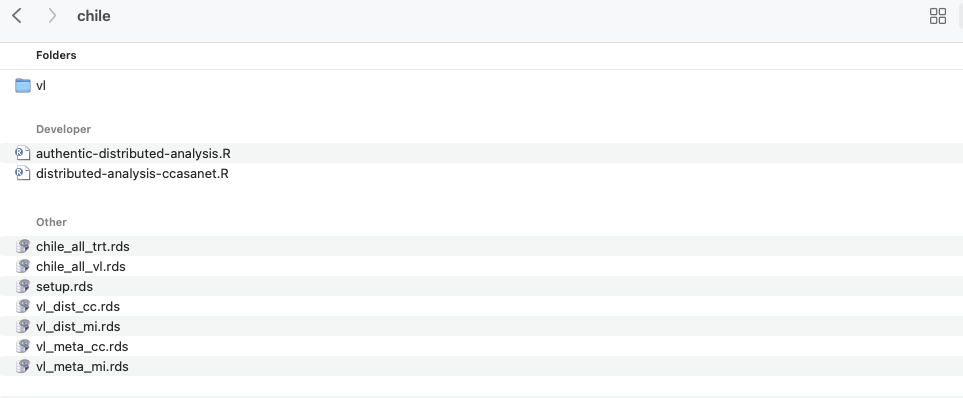

**—You are Done for federated analysis in this scenario.—**

**Regarding Major Regimen Change, we just repeat the above procedures.**

### 2.3 Major Regimen Change, Complete-Case Analysis

**Initialization**

1. Chile runs the command below.

   After running this, there will be a `control.json` file in the newly generated directory, `"trt/complete-case"` in the chosen local directory.

   ```r
   control <- list(project_name = 'major_regimen_change_distributed_survival_analysis_ccasanet',
                   step = 'initialize',
                   sites = c("chile", "brazil", "mexico"),
                   heterogeneity = TRUE,
                   model = 'ODAC',
                   family = 'cox',
                   outcome = "Surv(ARTchange_status.years, ARTchange_status==\"major treatment change\")",
                   variables = c('sex_mode', 'age', 'clinicalAIDS', 'cd4_v_initial_sqrt', 'rna_v_initial_log', 'calendaryear', 'initialARTtype'),
                   xlev = list(sex_mode=c('Female','Male-MSM', 'Male-Other'),  clinicalAIDS=c('Not clinical AIDS','Clinical AIDS'), initialARTtype=c('NNRTI','PI','INSTI')),
                   optim_maxit = 10000,
                   init_method = "meta",
                   optim_method = "Nelder-Mead",
                   lead_site = "chile",
                   upload_date = as.character(Sys.time()))
   set.seed(setup[["seed"]])
   pda.setup(leadsite = "chile", control, dir = getwd(), m = 1, complete = TRUE, outcome = "trt")
   ```

   **CHECK similarly**
2. Chile shall upload the `control.json` file in `"./trt/complete-case"` to the `"./trt/complete-case"` directory in the cloud.

   **—Wait for Brazil and Mexico to upload their `_initialize.json` file to the cloud.—**
3. After downloading `brazil_initialize.json` and `mexico_initialize.json` in the `"./trt/complete-case"` directory in OneDrive to local `"./trt/complete-case"` directory,

   **CHECK similarly as the case for virologic failure**

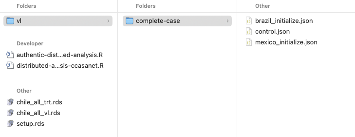

   Then run the command below. The same `control.json` file will be updated automatically.

   ```r
   set.seed(setup[["seed"]])
   pda.local(chile.trt.cc, "chile", getwd(), m = 1, complete = TRUE, outcome = "trt")
   ```

   **CHECK similarly**

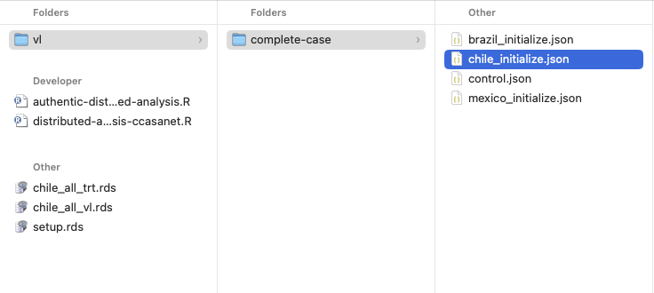

   and

   The “step” in `control.json` file in `"./trt/complete-case"` should be “derive” now (you can just open the `control.json` file or preview it if possible).
4. Chile uploads the updated `control.json` file in `"./trt/complete-case"` in local machine to `"./trt/complete-case"` in OneDrive.

**Derivation**

**—Wait for Brazil and Mexico to upload their `_derive.json` file.—**

1. After downloading `brazil_derive.json` and `mexico_derive.json` from `"./trt/complete-case"` in the cloud to local `"./trt/complete-case"`,

   **CHECK similarly as the case for virologic failure**

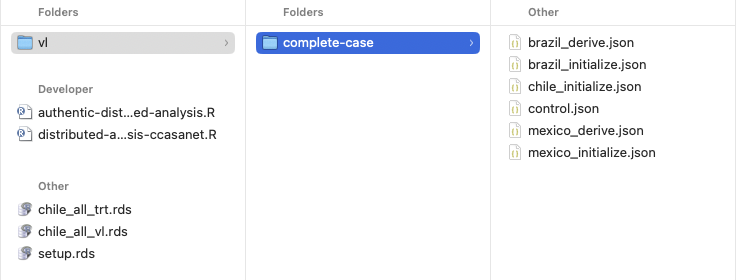

   Then run the command below.

   ```r
   set.seed(setup[["seed"]])
   pda.derive(chile.trt.cc, "chile", getwd(), m = 1, complete = TRUE, outcome = "trt")
   ```

   **CHECK similarly (`chile_derive.json`)**

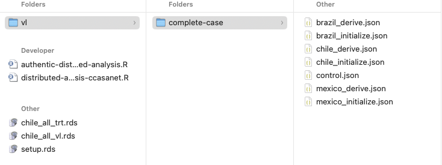

   and

   the “step” in `control.json` file in `"./trt/complete-case"` should be “estimate” now (you can just open the `control.json` file or preview it if possible).

**Estimation**

1. Chile runs this.

   ```r
   set.seed(setup[["seed"]])
   pda.estimate(chile.trt.cc, "chile", getwd(), m = 1, complete = TRUE, outcome = "trt")
   ```

   **CHECK similarly (`chile_estimate.json`)**

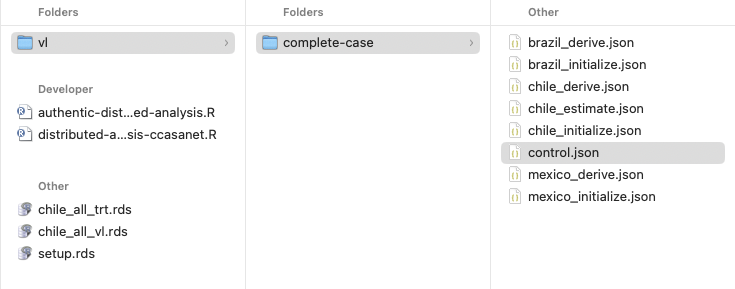

**Results**

1. Chile runs this.

```r
trt.dist.cc = pda.summary("chile", c("brazil", "mexico"), getwd(), 1, complete = TRUE, outcome="trt")
saveRDS(trt.dist.cc, file = "trt_dist_cc.rds")

trt.meta.cc = meta.mi(dist.meta(c("chile", "brazil", "mexico"), getwd(), 1, complete = TRUE, outcome="trt"))
saveRDS(trt.meta.cc, file = "trt_meta_cc.rds")
```

2. **CHECK** and upload `trt_dist_cc.rds` and `trt_meta_cc.rds` in the local directory to parental OneDrive folder.

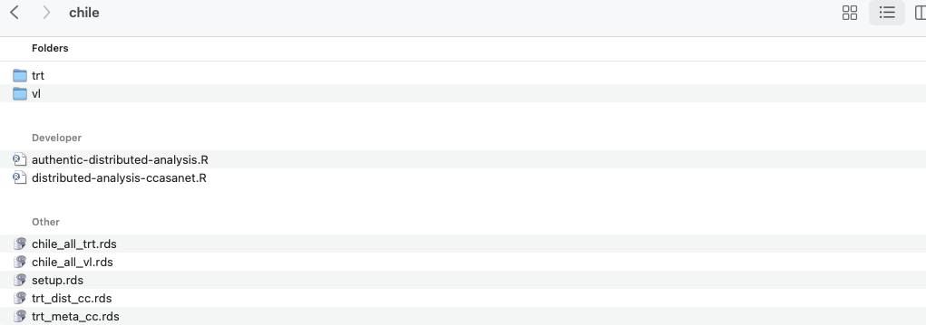

**—You are Done for federated analysis in this scenario.—**

Now you probably get familiar with the procedure.

For major regimen change with multiple imputation later, the procedures are the same overall except that we will do this per imputed data set.

No worries. The command given below realize this in parallel and this means you still just need run it once.

But you need do more when downloading and uploading files since we have multiple imputed data sets.

### 2.4 Major Regimen Change, with Multiple Imputation

**Initialization**

1. Chile runs the command below.

   ```r
   control <- list(project_name = 'major_regimen_change_distributed_survival_analysis_ccasanet',
                   step = 'initialize',
                   sites = c("chile", "brazil", "mexico"),
                   heterogeneity = TRUE,
                   model = 'ODAC',
                   family = 'cox',
                   outcome = "Surv(ARTchange_status.years, ARTchange_status==\"major treatment change\")",
                   variables = c('sex_mode', 'age', 'clinicalAIDS', 'cd4_v_initial_sqrt', 'rna_v_initial_log', 'calendaryear', 'initialARTtype'),
                   xlev = list(sex_mode=c('Female','Male-MSM', 'Male-Other'),  clinicalAIDS=c('Not clinical AIDS','Clinical AIDS'), initialARTtype=c('NNRTI','PI','INSTI')),
                   optim_maxit = 10000,
                   init_method = "meta",
                   optim_method = "Nelder-Mead",
                   lead_site = "chile",
                   upload_date = as.character(Sys.time()))
   set.seed(setup[["seed"]])
   pda.setup(leadsite = "chile", control, dir = getwd(), m = setup[["no.of.imputation"]], outcome = "trt")
   ```

   **CHECK similarly (newly generated directories indexed by number 1-10 in `./vl` and `control.json` file within each number-indexed directory)**

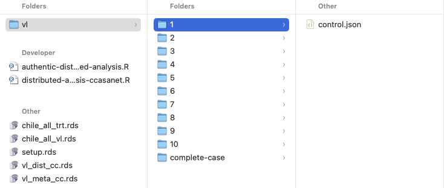

   and

   the “step” in `control.json` file in `"./trt/1"` should be “initialize” (you can just open the `control.json` file or preview it if possible).
2. Chile uploads each `control.json` file in the number-indexed directory to corresponding number-indexed directory in OneDrive.

   **—Wait for Brazil and Mexico to obtain and upload their `_initialize.json` file.—**
3. After downloading each pair of `brazil_initialize.json` and `mexico_initialize.json` in the number-indexed directory in OneDrive to corresponding local number-indexed directory,

   **CHECK similarly**

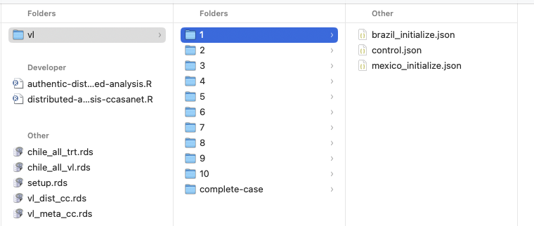

   Run the command below. The same `control.json` file will be updated automatically.

   ```r
   set.seed(setup[["seed"]])
   pda.local(chile.trt.mi, "chile", getwd(), m = setup[["no.of.imputation"]], outcome = "trt")
   ```

   **CHECK similarly (`chile_initialize.json`)**

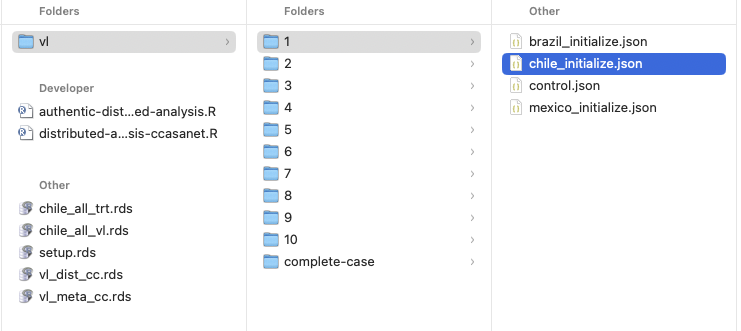

   and

   the “step” in `control.json` file in `"./trt/1"` should be “derive” (you can just open the `control.json` file or preview it if possible).
4. Chile updates each `control.json` file in the number-indexed directory to corresponding number-indexed directory in OneDrive.

**Derivation**

**—Wait for Brazil and Mexico to upload their `_derive.json` file.—**

1. After downloading each pair of `brazil_derive.json` and `mexico_derive.json` in number-indexed directories in OneDrive to corresponding local number-indexed directories,

   **CHECK similarly**

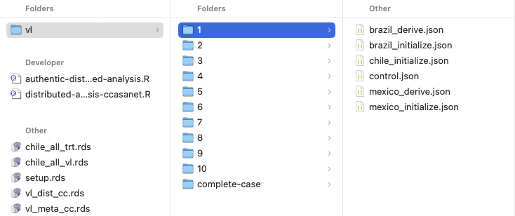

   Then run the command below.

   ```r
   set.seed(setup[["seed"]])
   pda.derive(chile.trt.mi, "chile", getwd(), m = setup[["no.of.imputation"]], outcome="trt")
   ```

   **CHECK similarly**

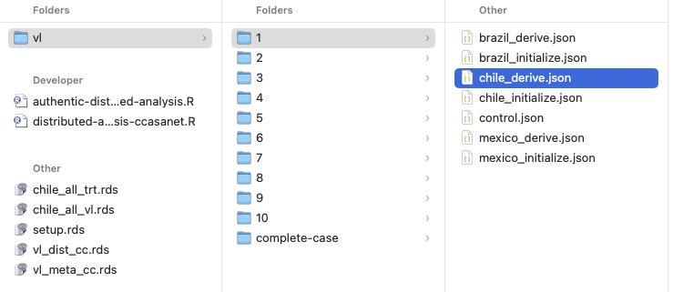

   and

   the “step” in `control.json` file in `"./trt/1"` should be “estimate” (you can just open the `control.json` file or preview it if possible).

**Estimation**

1. Chile runs this.

   ```r
   set.seed(setup[["seed"]])
   pda.estimate(chile.trt.mi, "chile", getwd(), m = setup[["no.of.imputation"]], outcome="trt")
   ```

**Results**

1. Chile runs this.

```r
trt.dist.mi = pda.summary("chile", c("brazil", "mexico"), getwd(), m = setup[["no.of.imputation"]], outcome="trt")
saveRDS(trt.dist.mi, file = "trt_dist_mi.rds")

trt.meta.mi = meta.mi(dist.meta(c("chile", "brazil", "mexico"), getwd(), m = setup[["no.of.imputation"]], outcome="trt"))
saveRDS(trt.meta.mi, file = "trt_meta_mi.rds")
```

2. **CHECK** and upload `trt_dist_mi.rds` and `trt_meta_mi.rds` in the local directory to parental OneDrive folder.

**—You are Done for federated analysis in this scenario.—**